# Praca domowa 3

Michał Gwóźdź

## Wizualizacja Źródłowa

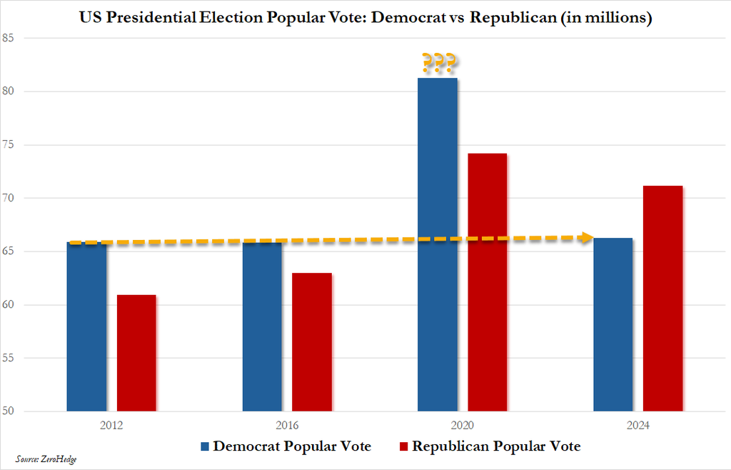

US Elections Visualization by ZeroHedge

**Komentarz:** Oryginalny wykres wydaje się mieć intencję sugerowania nieprawidłowości w wyborach prezydenckich w USA w 2020 roku. Jest to widoczne poprzez zastosowanie przerywanej linii, która odnosi się do poziomu głosów oddanych na Demokratów w poprzednich wyborach, co może sugerować, że ich znaczący wzrost w 2020 roku jest podejrzany lub niewiarygodny. Tego rodzaju prezentacja danych, opublikowana przez stronę internetową o wyraźnych politycznych inklinacjach, w tym przypadku ZeroHedge, wydaje się mieć na celu podważenie wyników wyborów i promowanie narracji o rzekomym fałszerstwie wyborczym („election fraud”). Problematyczne jest to, że dane są przedstawione w sposób wprowadzający w błąd. Po pierwsze, skala osi Y nie zaczyna się od zera, co znacznie wyolbrzymia różnice między wartościami. Przykładowo, liczba głosów oddanych na Demokratów w 2020 roku wydaje się ponad dwukrotnie większa niż w 2016 roku, podczas gdy w rzeczywistości różnica wynosi około 15 milionów głosów. Po drugie, wykresowi brakuje kontekstu, ponieważ liczba głosów w 2024 roku jest porównywana z zakończonymi wyborami z poprzednich lat, mimo że wizualizacja została opublikowana przed oficjalnym zakończeniem liczenia głosów. Ponadto wykres nie podaje precyzyjnych wartości liczbowych na słupkach, co utrudnia analizę i porównywanie danych.

Źródło: https://archive.ph/2024.11.08-173350/https://x.com/zerohedge/status/1854144250562429081

## Poprawiona Wersja

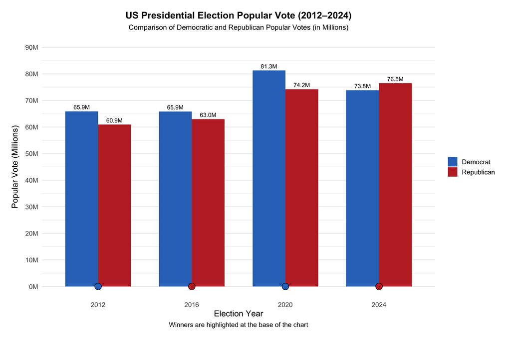

```r
p <- ggplot(data_long, aes(x = factor(Year), y = Votes_Millions, fill = Party)) +
  geom_col(position = "dodge", width = 0.7) +
  geom_text(aes(label = sprintf("%.1fM", Votes_Millions)),
            position = position_dodge(width = 0.7),
            vjust = -0.5, size = 3.5) +
  geom_point(data = df_cleaned %>% filter(Dem.Elected),
             aes(x = factor(Year), y = 0),
             size = 5, shape = 21, fill = "#2E74C0") +
  geom_point(data = df_cleaned %>% filter(!Dem.Elected),
             aes(x = factor(Year), y = 0),
             size = 5, shape = 21, fill = "#C02E2E") +
  scale_y_continuous(
    breaks = seq(0, 90, 10),
    limits = c(0, 90),
    labels = function(x) paste0(x, "M")
  ) +
  scale_fill_manual(values = c("Democrat" = "#2E74C0", "Republican" = "#C02E2E")) +
  labs(
    title = "US Presidential Election Popular Vote (2012–2024)",
    subtitle = "Comparison of Democratic and Republican Popular Votes (in Millions)",
    x = "Election Year",
    y = "Popular Vote (Millions)",
    caption = "Winners are highlighted at the base of the chart"
  ) +
  theme_minimal(base_size = 14) +
  theme(
    plot.title = element_text(face = "bold", hjust = 0.5, size = 16),
    plot.subtitle = element_text(hjust = 0.5, size = 12),
    axis.title.x = element_text(hjust = 0.5),
    axis.title.y = element_text(hjust = 0.5, margin = margin(r = 10)),
    legend.position = "right",
    legend.title = element_blank(),
    legend.justification = "center",
    panel.grid.major.x = element_blank(),
    plot.caption = element_text(hjust = 0.5),
    plot.margin = margin(t = 20, r = 20, b = 20, l = 20)
  )

ggsave("election_plot.png", p, width = 12, height = 8, dpi = 300)
knitr::include_graphics("election_plot.png")
```

**Komentarz:** Poprawiona wersja wykresu nie tylko naprawia wyżej wymienione błędy techniczne, ale również eliminuje potencjalnie manipulacyjny przekaz. Skala osi Y zaczyna się od zera, co pozwala na zachowanie właściwych proporcji między liczbą głosów w poszczególnych latach i eliminuje efekt wyolbrzymienia różnic. Dodatkowo podane są konkretne wartości, co czyni dane bardziej przejrzystymi i trudniejszymi do nadinterpretacji. Wykres także nie próbuje sugerować żadnych teorii spiskowych, lecz przedstawia dane w obiektywny sposób, uwzględniając oficjalne dane z Federal Election Commission Reports dla 2024 roku (po zakończeniu wyborów).

Źródło: Federal Election Commission Reports